# CA 3 original

# same interpretation has above though small size has much larger data and contains outliers

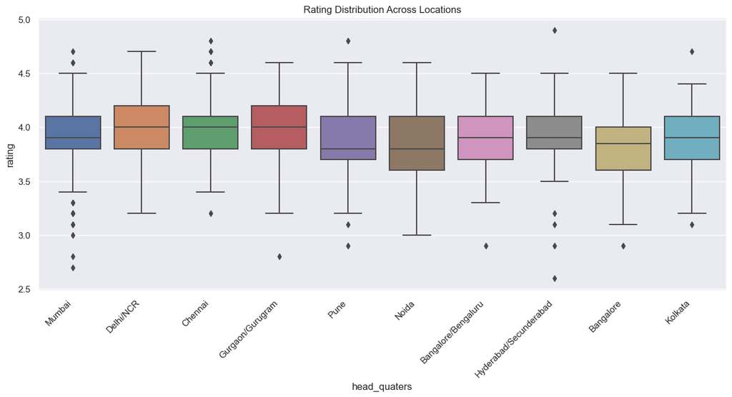

```python
plt.figure(figsize=(15, 6))
sns.boxplot(data =df1, x='head_quaters', y='rating', order=df1['head_quaters'].value_counts().index[0:10])
plt.xticks(rotation=45, ha='right')
plt.title('Rating Distribution Across Locations')
plt.show()
```

# Delhi, chennai and Gurugram have rating median rating of 4 others have less than that with noida has the least rating.

# some have outliers in them

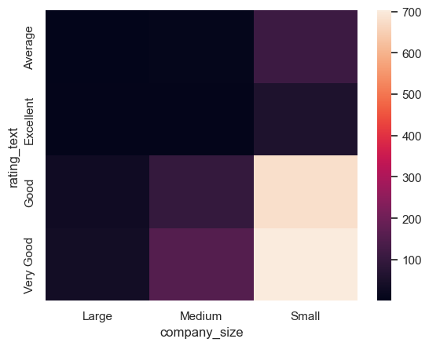

```python
sns.heatmap(pd.crosstab(df1['rating_text'],df1['company_size']))
```

# Interpretation : data has small company size as the most with good and very good rating

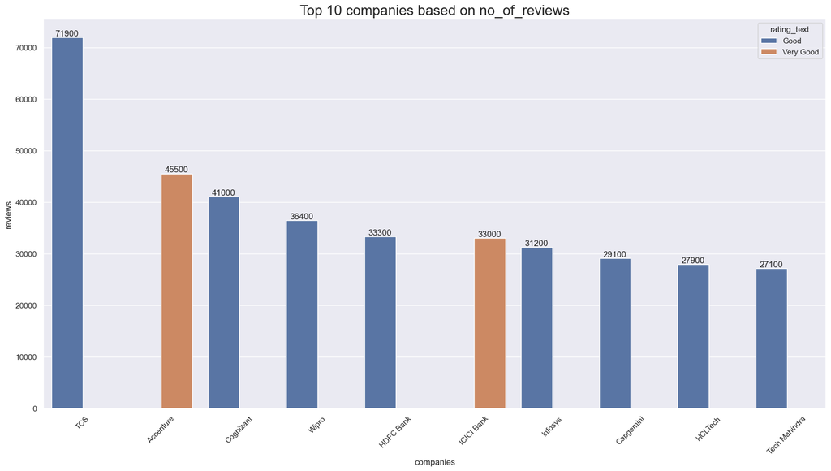

```python
ten_company_rating = df1.sort_values(by='reviews', ascending=False).head(10)

plt.figure(figsize=(20, 10))
head = sns.barplot(x=ten_company_rating['name'], y=ten_company_rating['reviews'], hue=ten_company_rating['rating_text'])
plt.xlabel('companies')
plt.ylabel('reviews')
plt.xticks(rotation=45)
plt.title('Top 10 companies based on no_of_reviews', fontsize=20)

for container in head.containers:
    head.bar_label(container)

plt.show()
```

# Most of them have good reviews expect accenture and ICICI bank which has very good rating

# TCS has reviews of 71900

```python
df1.head()
```

[output not shown]

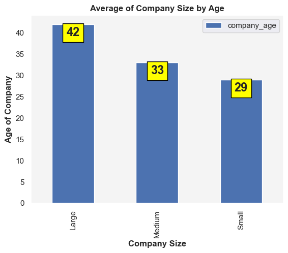

```python
comp_size_age = df1.groupby('company_size')['company_age'].median().reset_index()

plt.figure(figsize = (10,6))
p = comp_size_age.plot(x='company_size', y='company_age', kind='bar')

plt.title('Average of Company Size by Age', fontsize=12, fontweight='bold')
plt.xlabel('Company Size', fontsize=12, fontweight='bold')
plt.ylabel('Age of Company', fontsize=12, fontweight='bold')

for container in p.containers:
    plt.bar_label(container,
                padding = -20,
                fontsize = 17,
                bbox = {'boxstyle': 'square', 'edgecolor': 'black', 'facecolor': 'yellow'},
                label_type="edge",
                fontweight = 'bold'
                 )

# Customize the background color
p.set_facecolor("#f4f4f4")

# Remove the grid lines
p.grid(False)

plt.show()
```

# Large companies have median age of 42

# medium companies have median age of 33

# small companies have median age of 29

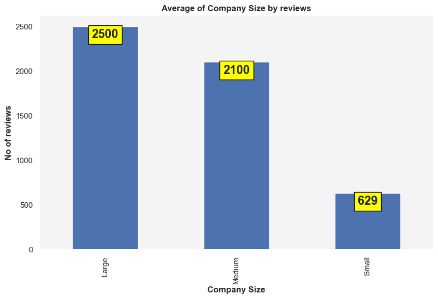

```python
comp_size_review = df1.groupby('company_size')['reviews'].median()

plt.figure(figsize = (10,6))
p = comp_size_review.plot(x='company_size', y='reviews', kind='bar')

plt.title('Average of Company Size by reviews', fontsize=12, fontweight='bold')
plt.xlabel('Company Size', fontsize=12, fontweight='bold')
plt.ylabel('No of reviews', fontsize=12, fontweight='bold')

for container in p.containers:
    plt.bar_label(container,
                padding = -20,
                fontsize = 17,
                bbox = {'boxstyle': 'square', 'edgecolor': 'black', 'facecolor': 'yellow'},
                label_type="edge",
                fontweight = 'bold'
                 )

# Customize the background color
p.set_facecolor("#f4f4f4")

# Remove the grid lines
p.grid(False)

plt.show()
```

# Large companies has 2500 reviews which is highest (median)

# Medium companies has 2100 reviews (mediam)

# small companies has 629 review (median)